# NEW YORK CITY TAXI DATA ANALYSIS

#### Removing Skewness : Applying a sqrt. function seems to cause the results to skew to the other side

[output not shown]

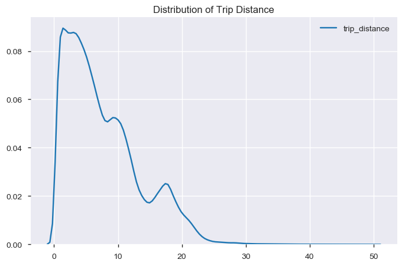

[figure not shown]

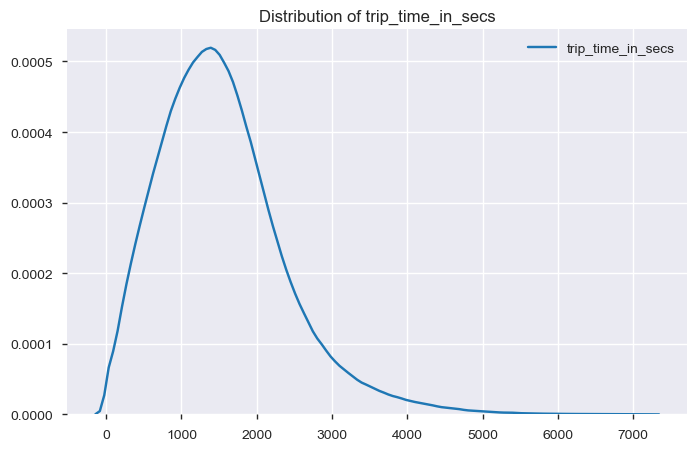

[figure not shown]

```python
plt.figure(figsize=(8,5))
sns.kdeplot(basic_model_fare_amt.trip_distance).set_title("Distribution of Trip Distance")

plt.figure(figsize=(8,5))
sns.kdeplot(np.sqrt(basic_model_fare_amt.trip_distance.values)).set_title("Distribution of Trip Distance (sqrt scale)")


plt.figure(figsize=(8,5))
sns.kdeplot(basic_model_fare_amt.trip_time_in_secs).set_title("Distribution of trip_time_in_secs")

plt.figure(figsize=(8,5))
sns.kdeplot(np.sqrt(basic_model_fare_amt.trip_time_in_secs.values)).set_title("Distribution of trip_time_in_secs (sqrt scale)")
```

```python
basic_model_fare_amt_sqrt = copy.deepcopy(basic_model_fare_amt)
basic_model_fare_amt_sqrt["trip_distance_sqrt"] = np.sqrt(basic_model_fare_amt_sqrt.trip_distance.values)
basic_model_fare_amt_sqrt["trip_time_in_secs_sqrt"] = np.sqrt(basic_model_fare_amt_sqrt.trip_time_in_secs.values)
basic_model_fare_amt_sqrt.drop(columns=["trip_distance","trip_time_in_secs"],inplace=True)
```

#### Data Splitting into Train and Validation sets

```python
X=basic_model_fare_amt.drop(['fare_amount'],axis=1)
y=basic_model_fare_amt['fare_amount']
X_train, X_test, y_train, y_test = train_test_split(X,y, test_size=0.3,random_state=5)
#test_size is the proportion of data that is to be kept aside for validation
```

```python
X_sqrt=basic_model_fare_amt_sqrt.drop(['fare_amount'],axis=1)
y_sqrt=basic_model_fare_amt_sqrt['fare_amount']
X_train_sqrt, X_test_sqrt, y_train_sqrt, y_test_sqrt = train_test_split(X_sqrt,y_sqrt, test_size=0.3,random_state=5)
#test_size is the proportion of data that is to be kept aside for validation
```

#### Build a Model based on average results

```python
avg_fare=round(np.mean(y_train),2) #11.31
baseline_pred=np.repeat(avg_fare,y_test.shape[0])
baseline_rmse=np.sqrt(mean_squared_error(baseline_pred, y_test))
print("Baseline RMSE of Test data :",baseline_rmse)
```

```
Baseline RMSE of Test data : 16.281321249691153
```

```python
avg_fare=round(np.mean(y_train_sqrt),2) #11.31
baseline_pred=np.repeat(avg_fare,y_test_sqrt.shape[0])
baseline_rmse=np.sqrt(mean_squared_error(baseline_pred, y_test_sqrt))
print("Baseline RMSE of Test data :",baseline_rmse)
```

```
Baseline RMSE of Test data : 16.281321249691153
```

#### Train Linear Regression model with simple features

```python
#Train Model
lm = LinearRegression()
lm.fit(X_train,y_train)

# Get Predictions
y_pred=np.round(lm.predict(X_test),2)

# Calculate Root Mean Squared Error
lm_rmse=np.sqrt(mean_squared_error(y_pred, y_test)) # Test/Validation RMSE
lm_train_rmse=np.sqrt(mean_squared_error(lm.predict(X_train), y_train)) # Training RMSE
lm_variance=abs(lm_train_rmse - lm_rmse)


print("Test RMSE for Linear Regression is ",lm_rmse)
print("Train RMSE for Linear Regression is ",lm_train_rmse)
print("Variance for Linear Regression is ",lm_variance)
```

```
Test RMSE for Linear Regression is  7.025379801299841
Train RMSE for Linear Regression is  6.898800778131946
Variance for Linear Regression is  0.1265790231678947
```

```python
#Train Model
lm = LinearRegression()
lm.fit(X_train_sqrt,y_train_sqrt)

# Get Predictions
y_pred_sqrt=np.round(lm.predict(X_test_sqrt),2)

# Calculate Root Mean Squared Error
lm_rmse=np.sqrt(mean_squared_error(y_pred_sqrt, y_test_sqrt)) # Test/Validation RMSE
lm_train_rmse=np.sqrt(mean_squared_error(lm.predict(X_train_sqrt), y_train_sqrt)) # Training RMSE
lm_variance=abs(lm_train_rmse - lm_rmse)


print("Test RMSE for Linear Regression is ",lm_rmse)
print("Train RMSE for Linear Regression is ",lm_train_rmse)
print("Variance for Linear Regression is ",lm_variance)
```

```
Test RMSE for Linear Regression is  7.157451279648323
Train RMSE for Linear Regression is  7.021852713619616
Variance for Linear Regression is  0.13559856602870735
```

##### Conclusion on Linear Regression model :

- The test RMSE for Linear Regression model was 7.025, and the training RMSE was 6.89.
- The test RMSE for Linear Regression model (with sqrt applied to trip duration and distance) was 7.15, and the training RMSE was 7.02, a slight deprovement versus no transformation.
- Both models are an improvement on the baseline prediction, with RMSE = 16.28.
- However, the error rate is still very high in the models

Step 2. Decision Tree

```python
#Train Model
dtr = DecisionTreeRegressor(random_state = 5)
dtr.fit(X_train,y_train)

# Get Predictions
dtr_pred= dtr.predict(X_test)

# Calculate Root Mean Squared Error
dtr_rmse=np.sqrt(mean_squared_error(dtr_pred, y_test))  # Test/Validation RMSE
dtr_train_rmse = np.sqrt(mean_squared_error(dtr.predict(X_train), y_train)) # Training RMSE
dtr_variance=abs(dtr_train_rmse - dtr_rmse)


print("Test RMSE for Decision Tree is ",dtr_rmse)
print("Train RMSE for Decision Tree is ",dtr_train_rmse)
print("Variance for Decision Tree is ",dtr_variance)
```

```
Test RMSE for Decision Tree is  5.720701466522035
Train RMSE for Decision Tree is  2.0940807730461937
Variance for Decision Tree is  3.6266206934758416
```

##### Conclusion on Decision Tree model :

- The test RMSE for Decision Tree model was 5.72, and the training RMSE was 2.09.
- This is an improvement over the Linear Regression model
- However, the variance is very high in the decision tree mode
- The high variance plus huge difference btwn train and test RMSE is a sign of overfitting occurring.

Step 3. Random Forest

```python
rf = RandomForestRegressor(n_estimators = 100, random_state = 5,n_jobs=-1)
rf.fit(X_train,y_train)
rf_pred= rf.predict(X_test)
rf_rmse=np.sqrt(mean_squared_error(rf_pred, y_test))
print("RMSE for Random Forest is ",rf_rmse)
```

[output not shown]

```python
#Train Model
rf = RandomForestRegressor(n_estimators = 100, random_state = 5,n_jobs=-1)
rf.fit(X_train,y_train)

# Get Predictions
rf_pred= rf.predict(X_test)

# Calculate Root Mean Squared Error
rf_rmse=np.sqrt(mean_squared_error(rf_pred, y_test))  # Test/Validation RMSE
rf_train_rmse = np.sqrt(mean_squared_error(rf.predict(X_train), y_train)) # Training RMSE
rf_variance=abs(rf_train_rmse - rf_rmse)


print("Test RMSE for Random Forest Regressor is ",rf_rmse)
print("Train RMSE for Random Forest Regressor is ",rf_train_rmse)
print("Variance for Random Forest Regressor is ",rf_variance)
```

```
Test RMSE for Random Forest Regressor is  4.8108950917374615
Train RMSE for Random Forest Regressor is  2.504055136003036
Variance for Random Forest Regressor is  2.3068399557344255
```

```python
#Train Model with different parameters
rf = RandomForestRegressor(random_state = 5,n_estimators = 20, max_depth = 20,
                                           n_jobs = -1)
rf.fit(X_train,y_train)

# Get Predictions
rf_pred= rf.predict(X_test)

# Calculate Root Mean Squared Error
rf_rmse=np.sqrt(mean_squared_error(rf_pred, y_test))  # Test/Validation RMSE
rf_train_rmse = np.sqrt(mean_squared_error(rf.predict(X_train), y_train)) # Training RMSE
rf_variance=abs(rf_train_rmse - rf_rmse)


print("Test RMSE for Random Forest Regressor is ",rf_rmse)
print("Train RMSE for Random Forest Regressor is ",rf_train_rmse)
print("Variance for Random Forest Regressor is ",rf_variance)
```

```
Test RMSE for Random Forest Regressor is  4.661222829920623
Train RMSE for Random Forest Regressor is  2.904628825766317
Variance for Random Forest Regressor is  1.7565940041543064
```

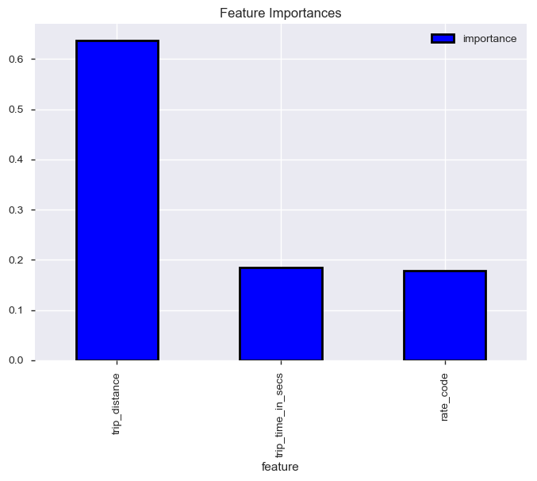

```python
# Extract feature importances
feature_importances = pd.DataFrame({'feature': X_train.columns.tolist(),
                                    'importance': rf.feature_importances_}).sort_values('importance', ascending = False).set_index('feature')

feature_importances.plot.bar(color = 'b', edgecolor = 'k', linewidth = 2);
plt.title('Feature Importances');
```

##### Conclusion on Random Forest model :

- The test RMSE for Random Forest model was 4.66 and train RMSE 2.90.
- RF model provides further improvement over the Decision Tree model.
- Variance has been lowered further to 1.75
- However, the difference between test and train RMSE may still be a sign of overfitting
- Tuning of parameters shows improvement to the results. Further hyperparameter tuning is required to provide even better results

Step 3. Gradient Boosted Model

```python
# !conda install -c conda-forge lightgbm
import lightgbm as lgb
```

```python
train_data=lgb.Dataset(X_train,label=y_train)
param = {'num_leaves':31, 'num_trees':5000,'objective':'regression'}
param['metric'] = 'l2_root'
num_round=5000
cv_results = lgb.cv(param, train_data, num_boost_round=num_round, nfold=10,verbose_eval=20, early_stopping_rounds=20,stratified=False)
lgb_bst=lgb.train(param,train_data,len(cv_results['rmse-mean']))
lgb_pred = lgb_bst.predict(X_test)

lgb_rmse=np.sqrt(mean_squared_error(lgb_pred, y_test))  # Test/Validation RMSE
lgb_train_rmse = np.sqrt(mean_squared_error(lgb.predict(X_train), y_train)) # Training RMSE
lgb_variance=abs(lgb_train_rmse - lgb_rmse)


print("Test RMSE for Light Gradient Boosted Model is ",lgb_rmse)
print("Train RMSE for Light Gradient Boosted Model is ",lgb_train_rmse)
print("Variance for Light Gradient Boosted Model is ",lgb_variance)
```

[output not shown]

### Conclusion on 1st round of model comparison:

- Random Forest Regressor model is the best model in the bunch
- We will continue to use RF Regressor for predicting Tip Amount

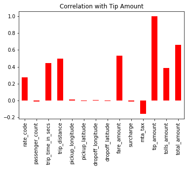

```python
corrs = trip_baseline.corr()
corrs['tip_amount'].plot.bar(color = 'r');
plt.title('Correlation with Tip Amount');
```

```python
basic_model_tip_amt = trip_baseline[['rate_code','trip_time_in_secs','trip_distance','tip_amount']]
basic_model_tip_amt.head()
```

```python
#Removal of nulls
# basic_model_tip_amt.d

#Drop Duplicates
print(basic_model_tip_amt.drop_duplicates(keep='first',inplace=True))
```

```python
#Data Splitting into Train and Validation sets
X=basic_model_fare_amt.drop(['fare_amount'],axis=1)
y=basic_model_fare_amt['fare_amount']
X_train, X_test, y_train, y_test = train_test_split(X,y, test_size=0.3,random_state=5)
#test_size is the proportion of data that is to be kept aside for validation
```

```python
#Build a Model based on average results
avg_fare=round(np.mean(y_train),2) #11.31
baseline_pred=np.repeat(avg_fare,y_test.shape[0])
baseline_rmse=np.sqrt(mean_squared_error(baseline_pred, y_test))
print("Baseline RMSE of Test data :",baseline_rmse)
```

```python
#Train RF Model with different parameters
rf = RandomForestRegressor(random_state = 5,n_estimators = 20, max_depth = 20,
                                           n_jobs = -1)
rf.fit(X_train,y_train)

# Get Predictions
rf_pred= rf.predict(X_test)

# Calculate Root Mean Squared Error
rf_rmse=np.sqrt(mean_squared_error(rf_pred, y_test))  # Test/Validation RMSE
rf_train_rmse = np.sqrt(mean_squared_error(rf.predict(X_train), y_train)) # Training RMSE
rf_variance=abs(rf_train_rmse - rf_rmse)


print("Test RMSE for Random Forest Regressor is ",rf_rmse)
print("Train RMSE for Random Forest Regressor is ",rf_train_rmse)
print("Variance for Random Forest Regressor is ",rf_variance)


# Extract feature importances
feature_importances = pd.DataFrame({'feature': X_train.columns.tolist(),
                                    'importance': rf.feature_importances_}).sort_values('importance', ascending = False).set_index('feature')

feature_importances.plot.bar(color = 'b', edgecolor = 'k', linewidth = 2);
plt.title('Feature Importances');
```

[output not shown]